# WORD RECOGNITION

### *Xabier Oyanguren Asua 1456628*

In what follows, a labelled word recording dataset is explored and used to generate predictive Neural Network models for the recognition of these words.

The employed dataset was obtained from Kaggle:

https://www.kaggle.com/c/tensorflow-speech-recognition-challenge/overview

In this dataset, we are offered *.wav* audio files of different people saying 20 words we would like to recognize:

["Yes", "No", "Up", "Down", "Left", "Right", "On", "Off", "Stop", "Go", "Zero", "One", "Two", "Three", "Four", "Five", "Six", "Seven", "Eight","Nine"]

Some additional audio files are given with background noise, together with some example words that should be classified as "unrecognized":

["Bed", "Bird", "Cat", "Dog", "Happy", "House", "Marvin", "Sheila", "Tree", "Wow"]

Thus, we have a total of 21 classes to classify.

## A) Pre-processing

We will first extract the audio files from the folders, check their sampling rates and durations and convert them into proper vectors to start processing them and think how to attack the problem.

```python
import os
import numpy as np
import pandas as pd
import matplotlib.pyplot as plt
from scipy import signal
from scipy.io import wavfile
from scipy.fft import fft, fftfreq
```

Looking at the categories that we find in the dataset:

```python
dataPath = "./data/train/audio"
all_audio_classes = os.listdir(dataPath) # the classes of the audio files we have
print(all_audio_classes)
```

```
['two', 'four', 'bird', 'five', 'on', 'left', 'dog', 'zero', 'bed', 'down', 'tree', 'sheila', 'eight', 'go', 'house', 'up', 'off', 'yes', 'stop', 'marvin', 'six', '_background_noise_', 'cat', 'three', 'one', 'no', 'happy', 'seven', 'right', 'nine', 'wow']
```

As already said, we will classify the elements not in classes_to_recognize as "unknown" words in general.

Note that for now we will avoid using the "background_noise" ones, as these files have more than 1 minute and thus would generate lots of samples more in "unknown", which as we see is already a category that is source of disbalance.

```python
all_audio_classes.remove('_background_noise_')
classes_to_recognize = ["yes", "no", "up", "down", "left", "right",
                        "on", "off", "stop", "go", "zero", "one",
                        "two", "three", "four", "five", "six", "seven",
                        "eight", "nine", "unknown"]
```

Next we get the file names with their respective class label in a same dataFrame.

```python
file_names_to_class={'word':[], 'file':[]}
for word in all_audio_classes:
    files_for_this_word = os.listdir(dataPath+'/'+word)
    for file in files_for_this_word:
        if word in classes_to_recognize:
            file_names_to_class['word'].append(word)
        else:
            file_names_to_class['word'].append('unknown')
        file_names_to_class['file'].append('/'+word+'/'+file)

datasetPD=pd.DataFrame.from_dict(file_names_to_class)
datasetPD
```

|  | word | file |
| --- | --- | --- |
| 0 | two | /two/eb3d8eb1_nohash_1.wav |
| 1 | two | /two/45adf84a_nohash_0.wav |
| 2 | two | /two/179a61b7_nohash_1.wav |
| 3 | two | /two/c120e80e_nohash_6.wav |
| 4 | two | /two/030ec18b_nohash_0.wav |
| ... | ... | ... |
| 64716 | unknown | /wow/0d53e045_nohash_0.wav |
| 64717 | unknown | /wow/9385508d_nohash_0.wav |
| 64718 | unknown | /wow/15c563d7_nohash_0.wav |
| 64719 | unknown | /wow/365531e2_nohash_0.wav |
| 64720 | unknown | /wow/d2eae23d_nohash_1.wav |

64721 rows × 2 columns

Looking at the number of samples per category:

```python
counts = datasetPD.groupby('word').count()
counts
```

| word | file |
| --- | --- |
| down | 2359 |
| eight | 2352 |
| five | 2357 |
| four | 2372 |
| go | 2372 |
| left | 2353 |
| nine | 2364 |
| no | 2375 |
| off | 2357 |
| on | 2367 |
| one | 2370 |
| right | 2367 |
| seven | 2377 |
| six | 2369 |
| stop | 2380 |
| three | 2356 |
| two | 2373 |
| unknown | 17373 |
| up | 2375 |
| yes | 2377 |
| zero | 2376 |

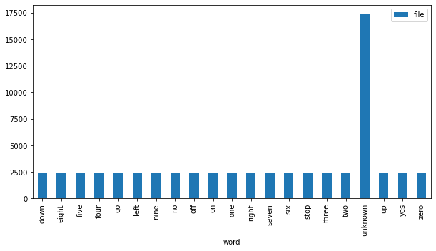

```python
counts.plot(kind='bar',figsize=(10,5))
plt.show()
```

Now, let us check the audio sample-rate for the recordings. Taking a random sample:

```
16000
16000
```

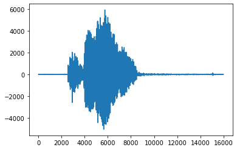

```python
sample_rate, samples = wavfile.read(dataPath + datasetPD['file'][15])
print(sample_rate)
print(len(samples))
plt.plot(samples)
plt.show()
```

We see that the signal was recorded with a sampling rate of 16kHz, that is, there are 16000 discrete digital air pressure recordings per second in an equispaced fashion. It turns out that the audio files are supposed to be 1 second long, so in principle they should have exactly 16000 samples. However this might not be exactly the case for all the recordings, so we better make sure that it is the case.

Analyising the sample rates and lengths for every signal in the dataset:

```python
sample_rates=set()
total_sample_numbers=set()
for file in datasetPD['file'].values:
    sample_rate, samples = wavfile.read(dataPath + file)
    sample_rates.add(sample_rate)
    total_sample_numbers.add(len(samples))
print(sample_rates)
print(total_sample_numbers)
print(max(total_sample_numbers))
```

```
{16000}
{16000, 14336, 12288, 10240, 15360, 8192, 12800, 11776, 13312, 15872, 11146, 7431, 11094, 14861, 9899, 15190, 7510, 14490, 14507, 10411, 6688, 10403, 14118, 12118, 8022, 8875, 15019, 12971, 10923, 6827, 11947, 7851, 15531, 13995, 8363, 15153, 9728, 10032, 13824, 8534, 5945, 9660, 7339, 11435, 13375,…
16000
```

So we can assert that there are only files with 16kHz sampling rate, but we found there are several total discrete recorded points.

Fortunately, the maximum number of discrete recorded points for a recording turns out to be 16000. That is, a duration of 1 second, as we expected.

In order to make all the sample vectors have the same length we will padd the sound recordings shorter than 1 second with 0-s until then.

If we do this, then we can directly generate the proper dataset. We will first set an ordinal encoding for the labels and then generate the arrays X (audio pulses) and y (labels):

```python
encoding={}
print('Class: -> Number:')
for index, classN in enumerate(classes_to_recognize):
    encoding[classN]= index
    print(classN," -> ", index)

y=[]
Xraw=[]
for word, file in zip(datasetPD['word'].values, datasetPD['file'].values):
    y.append(encoding[word])
    sample_rate, samples = wavfile.read(dataPath + file)
    Xraw.append( np.pad(samples, pad_width=(0, 16000-len(samples))) )

datasetPD['y']=y
datasetPD['Xraw']=Xraw
y=np.array(y)
Xraw=np.array(Xraw)
```

```
Class: -> Number:
yes  ->  0
no  ->  1
up  ->  2
down  ->  3
left  ->  4
right  ->  5
on  ->  6
off  ->  7
stop  ->  8
go  ->  9
zero  ->  10
one  ->  11
two  ->  12
three  ->  13
four  ->  14
five  ->  15
six  ->  16
seven  ->  17
eight  ->  18
nine  ->  19
unknown  ->  20
```

```python
print(Xraw.shape)
datasetPD
```

```
(64721, 16000)
```

|  | word | file | y | Xraw |
| --- | --- | --- | --- | --- |
| 0 | two | /two/eb3d8eb1_nohash_1.wav | 12 | [0, 0, 0, 0, 0, 0, 0, 0, 0, 0, 0, 0, 0, 0, 0, ... |
| 1 | two | /two/45adf84a_nohash_0.wav | 12 | [-16, -79, -47, -74, -74, 33, -16, -62, -8, -5... |
| 2 | two | /two/179a61b7_nohash_1.wav | 12 | [100, 64, 84, 33, -37, -40, -99, -95, -110, -1... |
| 3 | two | /two/c120e80e_nohash_6.wav | 12 | [-5, -3, -5, -5, -6, -5, -5, -3, -2, -6, -6, -... |
| 4 | two | /two/030ec18b_nohash_0.wav | 12 | [-10, 74, 57, 9, -3, 15, -66, -174, -144, -53,... |
| ... | ... | ... | ... | ... |
| 64716 | unknown | /wow/0d53e045_nohash_0.wav | 20 | [0, 0, 0, 0, 0, 0, 0, 0, 0, 0, 0, 0, 0, 0, 0, ... |
| 64717 | unknown | /wow/9385508d_nohash_0.wav | 20 | [-71, -102, -118, -123, -125, -124, -121, -128... |
| 64718 | unknown | /wow/15c563d7_nohash_0.wav | 20 | [22, 28, 36, 40, 39, 19, -8, -43, -63, -67, -7... |
| 64719 | unknown | /wow/365531e2_nohash_0.wav | 20 | [-52, -65, -73, -62, -80, -74, -72, -79, -77, ... |
| 64720 | unknown | /wow/d2eae23d_nohash_1.wav | 20 | [-20, -33, -31, -34, -26, -18, -10, 1, 6, 4, 1... |

64721 rows × 4 columns

We could now directly feed the machine learning algorithm with the vectorized 1D discrete audio signals, which represent the air pressure recorded at each sampled time.

However, we can help a bit the "machine" if we apply a bit of human mathematical pattern recognition: **Fourier decomposition**.

The Fourier decomposition of a finite support or periodic signal provides the infinite complex exponential expansion that best fits the signal function. These different exponent complex exponentials can be re-written as sines and cosines of different frequencies called harmonics, which conceptually means we can take each recording and decomopose it in its "underlying" frequencies.

There is a discrete version of this expansion called the Discrete Fourier Transform (DFT) that will allow us decompose our finite and discretized signals (the recordings) into a finite number of complex coefficients for a complex exponential sum that would allow the reconstruction of the recording (under certain conditions). Note that there is an algorithm that reduces the computational cost to compute the DFT called the Fast Fourier Transform (FFT). We will be using this algorithm in particular.

Let us see an example of applying the discrete decomposition in harmonics (DFT) for a random signal among our samples:

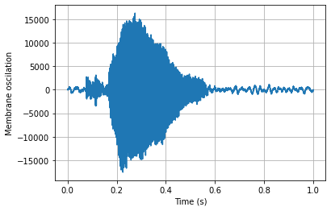

```python
sample_rate, samples = wavfile.read(dataPath + datasetPD['file'][13])

# number of total signal points
N = len(samples)

# sample spacing is 16000 smaples per second
T = 1.0 / sample_rate

times = np.linspace(0.0, N*T, N)

samplesFourierCoefs = fft(samples)

frecs = np.linspace(-1.0/(2.0*T), 1.0/(2.0*T), N)

plt.plot(times, samples)
plt.xlabel("Time (s)")
plt.ylabel("Membrane oscilation")
plt.grid()
plt.show()
```

```python
frecs = fftfreq(N,T)
```

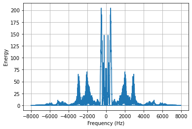

```python
plt.plot(frecs, 1.0/N * np.abs(samplesFourierCoefs))
plt.xlabel("Frequency (Hz)")
plt.ylabel("Energy")
plt.grid()
plt.show()
```

Where we have plotted the amplitude or coefficients of the linear sum of the exponentials/harmonics of each frequency (what we call Energy) against the frequency of their harmonics.

We see that the biggest part of the energy is concentrated in the lowest frequencies of the range. However, we need to keep track of the higher harmonics as well, as higher frequency harmonics are the ones that allow to reconstruct sharp edges of the original signal.

Also, note that we obtain a symetric frequency plot for positive and negative "frequencies", this is becasue the transformed signal was purely real, so in fact we will have enough with analysing half of the spectrum. We can indeed add the power of the symmetric frequencies to the positive ones and obtain a compacter Fourier coefficient series:

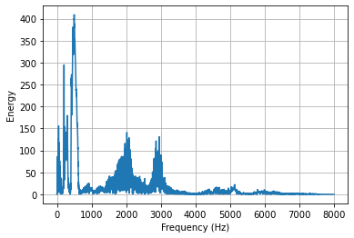

```python
frecs = np.linspace(0, 1.0/(2.0*T), N//2)

plt.plot(frecs, 2.0/N * np.abs(samplesFourierCoefs)[0:N//2])
plt.xlabel("Frequency (Hz)")
plt.ylabel("Energy")
plt.grid()
plt.show()
```

Now this same harmonic power spectrum could be ploted in colors with a brighter color for the most energetic frequencies:

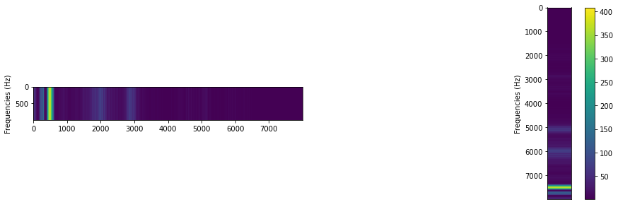

```python
fig = plt.figure(figsize=(15,5))
ax1= fig.add_subplot(121)
ax2= fig.add_subplot(122)

cm1 = ax1.imshow([2.0/N * np.abs(samplesFourierCoefs)[0:N//2] for i in range(1000)])
ax1.set_ylabel("Frequencies (Hz)")
plt.xticks([])

plt.imshow(np.array([2.0/N * np.flip(np.abs(samplesFourierCoefs)[0:N//2]) for i in range(1000)]).transpose())
plt.ylabel("Frequencies (Hz)")
plt.colorbar(cm1)
plt.xticks([])
plt.show()
```

Where again, the brighter the color, the higher the power in that frequency. The human voice has usually strong frequencies in the lower part of hte range we have plotted here, that is why the power is mostly concentrated in the lowest part in frequencies.

Now, as we have 16000 samples, instead of doing a single DFT in the whole recording as we have done above, we could do the following to have a finer grain vision of the signal: divide the full recording into small *window_num* signal windows and apply a Fourier decomposition to each of these simpler elements of the signal. This will help the "machine" recognize more atomic elements of speech like phonemes.

If we do this for *window_num* windows or signal pieces, we will obtain *window_num* DFT vectors, which will allow us plot *window_num* color maps like the one above. In fact, as they have a chronological order, we could take them vertically (as the second figure in the previous cell) and stack them horizontally in order. This would allow us obtain a 2D image!

Thus, we would have transformed the word recording into an image: a heatmpa plot of the Fourier decomposition per small window of the recording. This is called a spectrogram.

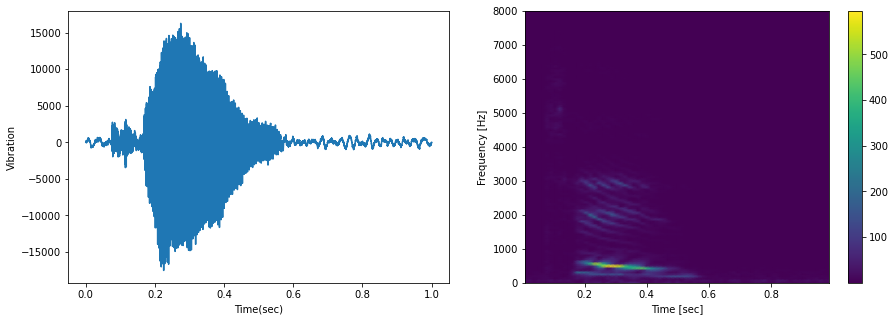

```python
frequencies, times, spectrogram = signal.spectrogram(samples,
                                                     sample_rate,
                                                     return_onesided=True,
                                                     mode='magnitude')

fig = plt.figure(figsize=(15,5))
ax1= fig.add_subplot(121)
ax1.plot(np.linspace(0.0, N*T, N), samples)
ax1.set_xlabel("Time(sec)")
ax1.set_ylabel("Vibration")

ax2=fig.add_subplot(122)
cm = ax2.pcolormesh(times, frequencies, spectrogram, shading='gouraud')
ax2.set_ylabel('Frequency [Hz]')
ax2.set_xlabel('Time [sec]')
plt.colorbar(cm)

plt.show()
```

We can see the same peaks we saw in the full signal but now concentrated around the time when there is sound. Clearly the detail level is higher now than when we only made a Fourier Decomposition for the whole word.

Also, note that even if the spectrogram seems to be empty, this is not true: let us watch it in a logarithmic scale.

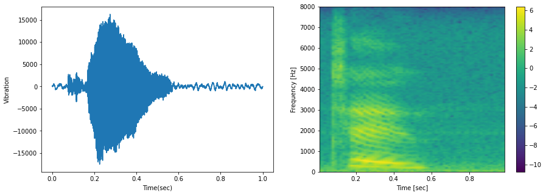

```python
fig = plt.figure(figsize=(15,5))
ax1= fig.add_subplot(121)
ax1.plot(np.linspace(0.0, N*T, N), samples)
ax1.set_xlabel("Time(sec)")
ax1.set_ylabel("Vibration")

ax2=fig.add_subplot(122)
cm = ax2.pcolormesh(times, frequencies, np.log(spectrogram), shading='gouraud')
ax2.set_ylabel('Frequency [Hz]')
ax2.set_xlabel('Time [sec]')
plt.colorbar(cm)

plt.show()
```

Now, there are several parameters in the spectrogram building. We will need to choose the window size, which is the lenght of each audio chunk, together with the filter shape, which is basically choosing the sample weight we will give to each point of the audio chunks in which we divide each recording. These weights are important because we will set an overlap between the chunks, that is, the first and last part of each chunk will be shared with the contiguous chunks, expecting that having a slight context in each "phoneme" will be helpful. Thus we might want to give less weight to the points that were already in the bulk of the previous chunk and to those that will appear too in the bulk of the following chunk.

As the present notebook does not pretend to be oriented towards a deep signal analysis, we will leave the scipy spectrogram algorithm choose the default values. According to the documentation:

- The default window shape is a Tukey window (a square wave with a smooth decay instead of a discontinuity) with shape parameter (smoothness of decay) of 0.25. It is basically the idea we said as example above: use a smaller weight for the boundaries of the window (the overlapped pieces).
- The length of the default window is 256 samples. In our 16kHz sampling rate signal, this means each window will have a length of 16ms. This seems to be fine to capture big parts of each phoneme.
- By default an overlap is set between consecutive chunks in which we divide the recording. The number of points to overlap between segments is 256/8 = 32. That is, each segment will start with the last 32 smaples of the previous segment (in our case 2ms) and will end with the first 32 samples of the next segment (2ms).

Thus, each chunk on which we will perform a FFT to build the spectrogram will have 16ms (256 samples) with 12ms (192 samples) of non-overlapped part in the middle and 2ms (32 smaples) at each edge shared with each contiguous chunks.

This means that we will have: $$ NumChunks = (int)\frac{TotalNumSamples-OverlapSamples}{OverlapSamples+NoOverlapSamples} = \frac{16000-32}{192+32}= 71 $$

That is, we will have 71 DFT profiles in total, where as each has 256 samples, each chunk will be casted into 256 frequencies in $[\frac{-1}{2T}, \frac{1}{2T}]=[-8000Hz,-8000Hz]$ with $T=samplingRate=16000s^{-1}$. As the signal is real, we will only care for one of the frequency signs, say $[0,-8000Hz]$. Which means, the FFT profile will have 256/2+1=129 frequency amplitudes for each of the consequtive 71 chunks in which we divide the recordings.

Aka, each spectrogram should extend 71 in time and 129 in frequencies.

Let us check if the scipy function does what we expected:

```python
print(spectrogram.shape)
```

```
(129, 71)
```

Which is exactly the expected shape. Note how in dimension/axis 0 of the tensor we have the frequencies of the magnitudes of the coefficients while in the dimension/axis 1 we have the ordered temporal chunk number for these coefficients.

Note how we have rationaly obtained a reduction of the data (no ML black box), as now instead of having 16000 features per recording, we just have $129*71=9159$ features (just 57.24%)! And in principle we have done it in a way that we minimize infromation loss (as we would be able to rebuild the original time domain recording$^1$ by the Nyquist Theorem), and at the same time we have made more explicit the patterns to be recognized!

Clearly the "machine" could have also learnt to implicitly make a FFT with enough data, if it is there where the key patterns to look at really are, but we can save her that work.

$^1$ = not fully true as we just left the magnitude of the FFT coeffs, but the idea holds.

Now, if we process the dataset in order to convert each of the recordings into its spectrogram, following the exact same recipy explained above:

```python
del Xraw
Xspectr=[]
sample_rate=16000
for audio in datasetPD['Xraw'].values:

    frequencies, times, spectrogram = signal.spectrogram(audio,
                                                     sample_rate,
                                                     return_onesided=True,
                                                     mode='magnitude')
    Xspectr.append(spectrogram)

dataset = pd.DataFrame(datasetPD['y'])
dataset['Xspectr']=Xspectr
dataset.to_pickle("./pre_processed_unormalized_dataset.pkl")

Xspectr=np.array(Xspectr)
Xspectr.shape
```

```
(64721, 129, 71)
```

We have now the dataset almost ready.

Perhaps as a last step in the Pre-processing we can Normalize the magnitudes of the Fourier coefficients for each recording to avoid distortions caused by scale differences, as each recording was made in a different user device in a different environment.

We could do it perhaps for each time chunk, but this would homogenize the silences in the audios with the parts with real talk. We could also do it for each frequency, but this would blur the differences in magnitude between different frequencies. Also, we could do the normalization using the mean and standard deviation of all the spectrograms in the dataset, but this might introduce a slight overfitting point, as it would be ad-hoc for the training set.

The best idea then seems to be to normalize each spectrogram independently with the mean and standrad deviation of all the flattened spectrogram (for the reasons we stated just above). Thus, if one got a new sample, before feeding it to the trained algorithm it would require a noramlization using its own mean and standard deviation.

Note that perhaps a more suitable normalization could be achieved first converting the energy coefficients into a logarithmic scale (dB for instance). However, here we will work with the plain absolute values of the coeffients (subtracting to them directly the mean and dividing them by their standard deviation).

```python
dataset=pd.read_pickle("./pre_processed_unormalized_dataset.pkl")
X=[]
for audioSpectrogram in dataset['Xspectr']:
    X.append((audioSpectrogram-audioSpectrogram.flatten().mean())/np.std(audioSpectrogram.flatten()))
X=np.array(X)
X.shape
```

```
(64721, 129, 71)
```

Before finsihing the data preprocessing, we have found that an error is outputted accounting for a division by zero. This is probably because there was a damaged recording that was a constant value, such that the standard deviation is zero. If we actually count the number of nans in the dataset:

```python
np.sum(np.isnan(X))
```

```
9159
```

We find there are 129*71=9159 nans. Suggesting it is a single recording file that was problematic. We will check that this is indeed the case and simply drop it from the dataset.

```python
containsNaN = np.sum(np.isnan(X), axis=(1,2))!=0
print(f"There are {np.sum(containsNaN) } recordings that contain a nan")
nanSample = np.argmax(containsNaN)
print(f"It is sample number {nanSample}")
X = np.delete(X, containsNaN, axis=0)
print(f"Now there are {X.shape[0]} samples in the dataset")
```

```
There are 1 recordings that contain a nan
It is sample number 4776
Now there are 64720 samples in the dataset
```

```python
dataset_normalized=pd.DataFrame(dataset.drop(nanSample, axis=0).reset_index(drop=True)
['y'])
dataset_normalized['X']=[x for x in X]
dataset_normalized.to_pickle("./pre_processed_dataset.pkl")
```

Finally, the dataset with 64720 samples is now ready for Machine Learning.

# B) Preparing the Environment for Machine Learning

Once we have the dataset ready in a pandas dataframe, we can just import it, together with all the torch modules necessary for the models we will be implementing:

```python
import numpy as np
import pandas as pd
import matplotlib.pyplot as plt
import torch
import torch.nn as nn
import tqdm
import sys
import seaborn as sns
import time
from sklearn.metrics import confusion_matrix


dataset_PD = pd.read_pickle("./pre_processed_dataset.pkl")
```

Now, before going to the model definitions, we will prepare the Learning environment, choosing all the parameters, defining the test and train loops, auxiliary analysis tools and of course, creating the torch dataloader.

## B.1) Parameter Selection

```python
# Parameters if one wnats a quick experiment
quick_experiment = False  # reduce the number of training and testing samples for a quick check
epochs_in_quick = 8      # number of epochs in the fast experiment
n_train_in_quick = 600  # number of training samples in the fast experiment
n_test_in_quick = 1000    # number of testing samples in the fast experiment

# General experiment parameters
epochs = 10             # number of epochs to train (default: 14)
learning_rate = 0.001   # learning rate (default: 0.001-[0.01]-0.1)
gamma = 0.7             # Learning rate step gamma (default: 0.7)

batch_size = 350      # number of samples per batch during training
test_batch_size = 1000  # number of samples per batch for testing

# coose if we want to use Nvidia GPU
no_cuda = False          # disables CUDA training
dry_run = False         # quickly check a single pass
seed = 666                # random seed (default: 1)
log_interval = 50       # how many batches to wait before logging training status
save_model = True      # For Saving the current Model


# Check if cuda is available
use_cuda = not no_cuda and torch.cuda.is_available()
print(f"USING CUDA: {use_cuda}")
torch.manual_seed(seed)

# define the device where to compute (cpu or gpu)
device = torch.device("cuda" if use_cuda else "cpu")

train_kwargs = {'batch_size': batch_size}
test_kwargs = {'batch_size': test_batch_size}
if use_cuda:
    cuda_kwargs = {'num_workers': 3,
                   'pin_memory': True,
                   'shuffle': True}
    train_kwargs.update(cuda_kwargs)
    test_kwargs.update(cuda_kwargs)
    print(torch.cuda.get_device_name())
```

```
USING CUDA: True
GeForce GTX 1660 SUPER
```

## B.2) Auxiliary Functions for Model and Result Analysis

```python
def visualize_confusion_matrix(y_pred, y_real):
    """
    Given the predictions by the model and the groundtruth, it computes and shows the Confusion Matrix.

    """
    cm = confusion_matrix(y_real, y_pred)
    plt.subplots(figsize=(10, 6))
    sns.heatmap(cm, annot = True, fmt = 'g')
    plt.xlabel("Predicted")
    plt.ylabel("Actual")
    plt.title("Confusion Matrix")
    plt.show()
    print("0:yes, 1:no, 2:up, 3:down, 4:left, 5:right, 6:on, 7:off, 8:stop, 9:go, 10:zero, 11:one, 12:two, 13:three, 14:four, 15:five, 16:six, 17:seven, 18:eight, 19:nine, 20:unknown")

def compute_model_parameter_number(current_model):
    """
    Given a torch model, it computes its number of trainable parameters.

    """
    pytorch_total_params = sum(p.numel() for p in current_model.parameters() if p.requires_grad)
    print("# trainable parameters: {:,}".format(pytorch_total_params))
    return pytorch_total_params

def compute_parameters_and_flops(current_model):
    """
    Given a troch model, it computes the number of parameters and flops per run of a predction.

    """
    from thop import profile
    test_input = torch.randn(1, 1, 129, 71).to('cuda')
    macs, params = profile(current_model, inputs=(test_input,))  # multiply accumulate operation (GFLOPS = 2 * GMACS)
    # normalment, en gpus i exemples reals, es parlaria minim de Gigaflops.
    # print("%s | %.2f Params(M) | %.3f FLOPs(G)" % (current_model._get_name(), params / (1000 ** 2), macs / (1000 ** 3)))
    print("%s | %.2f Params(M) | %.3f FLOPs(M)" % (current_model._get_name(), params / (1000 ** 2), macs / (1000 ** 2)))
    return macs, params

def show_model_structure_torchviz(current_model):
    """
    The tree structure of the model is shown as internally graphed by torch, using torchviz.

    """
    from torchviz import make_dot
    test_input = torch.randn(1, 1, 129, 71).to('cuda')
    return make_dot(current_model(test_input), params=dict(current_model.named_parameters()))


def show_model_structure_hiddenlayer(current_model):
    """
    A concise tree structure of the model is shown as seen by the library hiddenlayer.
    """
    import hiddenlayer as hl
    test_input = torch.randn(1, 1, 129, 71).to('cuda')
    hl_graph = hl.build_graph(current_model, test_input)
    return hl_graph
```

## B.3) Train and Test loops

```python
def train(model, device, train_loader, optimizer, criterion):
    """
    Execute one epoch worth training (see each sample once).
    """
    losses = []
    model.train() # train mode
    t = tqdm.tqdm(enumerate(train_loader), total=len(train_loader))
    t.set_description('Train')
    for batch_idx, (data, target) in t: # for each batch
        data, target = data.to(device), target.to(device) # send batch to device
        optimizer.zero_grad() # restart gradient
        loss = criterion( model(data), target) # compute prediciton of data for this batch and its loss
        loss.backward() # backpropagate the loss
        optimizer.step() # execute a gradient step
        torch.nn.utils.clip_grad_norm_(model.parameters(), 10) #clip the gradient to avoid overflow
        losses.append(loss.item()) # save loss for this batch
        t.set_postfix(loss=loss.item())

    return losses


def test(model, device, test_loader, criterion, confusion=False):
    """
    Execute a test of the model using the test-set.
    """
    model.eval() # evaluation mode
    test_loss = 0
    correct = 0
    totals = 0
    all_preds = []
    all_targets = []

    with torch.no_grad(): # avoid gradient computation
        t = tqdm.tqdm(test_loader, total=len(test_loader))
        t.set_description('Test ')
        for data, target in t: # for each batch
            data, target = data.to(device), target.to(device) # send batch to device
            output = model(data) # compute the prediction
            test_loss += criterion(output, target).item() * data.shape[0]  # sum up batch loss
            pred = output.argmax(dim=1, keepdim=True)  # get the index of the max log-probability
            correct += pred.eq(target.view_as(pred)).sum().item()
            totals += len(target) # annotate the number of correct predictions
            t.set_postfix(loss=test_loss/totals, accuracy=100.*correct/totals)
            all_preds.extend(pred)
            all_targets.extend(target)

    test_loss /= len(test_loader.dataset)
    accuracy = 100. * correct / len(test_loader.dataset)

    if confusion: # visualize confusion matrix
        visualize_confusion_matrix(np.asarray([pred.to('cpu') for pred in all_preds]).flatten(),
                                   np.asarray([target.to('cpu') for target in all_targets]).flatten())

    print('\nTest set: Average loss: {:.4f}, Accuracy: {}/{} ({:.2f}%)\n'.format(
        test_loss, correct, len(test_loader.dataset), accuracy))
    return test_loss, accuracy
```

## B.4) Experiment Loop

```python
def experiment(model, device, train_loss, test_loss, optimizer, train_loader,
               test_loader, scheduler, name='', save_model=False):
    """
    Function that executes a full training and testing for the globally defined number of epochs.
    Each training set sample will be evaluated epoch times. In each epoch the test set loss and accuracy
    are computed.
    """
    init_time = time.time() # record the elapsed time
    losses_train = []
    losses_test = []
    accuracies_test = []
    print('--'*50)
    print('STARTING EXPERIMENT {}'.format(name))
    print('--'*50)

    model.to(device) # send model to device
    for epoch in range(1, epochs + 1):
        print ("EPOCH {}".format(epoch))
        sys.stdout.flush()
        loss_train_epoch = train(model, device, train_loader, optimizer, train_loss) # execute train for this epoch
        loss_test_epoch, accuracy_epoch = test(model, device, test_loader, test_loss) # test as well
        scheduler.step()  # execute learning rate reduction

        losses_train.extend(loss_train_epoch)
        losses_test.append(loss_test_epoch)
        accuracies_test.append(accuracy_epoch)

    test(model, device, test_loader, loss, confusion=True) # last test for plotting confusion matrix
    plt.plot(range(len(losses_train)),
             losses_train, label="Training Loss") # plot test and train loss progression during training

    plt.plot(range(0, len(losses_train), int(len(losses_train)/(len(losses_test)-1))),
             losses_test, label="Test Loss")
    plt.legend()
    plt.ylim(0,2.8)
    plt.show()

    elapsed = time.time()-init_time

    if save_model: # save model if asked
        torch.save(model.state_dict(), name+"_Word_Recognition.pt")

    print ("ELAPSED TIME: {:.1f}s".format(elapsed))

    return losses_train, losses_test, accuracies_test, elapsed
```

## B.5) Data to Torch Dataloader

We randomly choose the indices for training and for testing, spliting the full dataset in an 85% for train and 15% for test.

```python
train_percentage = 0.85
dataset_size = len(dataset_PD)

train_size = int(train_percentage * dataset_size)
test_size = dataset_size - train_size

# A first shuffle of the dataset
dataset_PD = dataset_PD.sample(frac=1, random_state=666)

train_indices, test_indices = torch.utils.data.random_split(dataset_PD.index, [train_size, test_size])
```

We analyze whether the resulting test and train sets maintain the porportions in the different categories.

```python
train_dataset = dataset_PD.iloc[train_indices.indices]
test_dataset = dataset_PD.iloc[test_indices.indices]
```

```python
counts_train = train_dataset.groupby('y').count()
counts_test = test_dataset.groupby('y').count()
counts_original = dataset_PD.groupby('y').count()

pd.concat( [counts_original.rename(columns={'X':'% of samples in Full dataset'})/(train_size+test_size)*100,
                  counts_train.rename(columns={'X':'% of samples in Train set'})/train_size*100,
                  counts_test.rename(columns={'X':'% of samples in Test set'})/test_size*100 ], axis=1)
```

| y | % of samples in Full dataset | % of samples in Train set | % of samples in Test set |
| --- | --- | --- | --- |
| 0 | 3.672744 | 3.648295 | 3.811290 |
| 1 | 3.669654 | 3.697375 | 3.512567 |
| 2 | 3.669654 | 3.655566 | 3.749485 |
| 3 | 3.644932 | 3.677379 | 3.461063 |
| 4 | 3.635661 | 3.664655 | 3.471364 |
| 5 | 3.657293 | 3.675562 | 3.553770 |
| 6 | 3.657293 | 3.653748 | 3.677379 |
| 7 | 3.641842 | 3.644659 | 3.625876 |
| 8 | 3.677379 | 3.681015 | 3.656778 |
| 9 | 3.665019 | 3.655566 | 3.718583 |
| 10 | 3.671199 | 3.686468 | 3.584672 |
| 11 | 3.661928 | 3.650113 | 3.728883 |
| 12 | 3.666564 | 3.615575 | 3.955501 |
| 13 | 3.640297 | 3.655566 | 3.553770 |
| 14 | 3.665019 | 3.682833 | 3.564071 |
| 15 | 3.641842 | 3.597397 | 3.893696 |
| 16 | 3.660383 | 3.639206 | 3.780387 |
| 17 | 3.672744 | 3.675562 | 3.656778 |
| 18 | 3.634116 | 3.608304 | 3.780387 |
| 19 | 3.652658 | 3.630117 | 3.780387 |
| 20 | 26.841780 | 26.905039 | 26.483313 |

We finally create the Torch Dataloader, taking care of furhter slicing the test and train sets for the quick_experiment setup, in case it is activated.

```python
train_target = torch.tensor(train_dataset['y'].values)
train_data = torch.tensor(np.stack(train_dataset['X'].values)).unsqueeze(dim=1) # we add a single channel
train_tensors = torch.utils.data.TensorDataset(train_data, train_target)

test_target = torch.tensor(test_dataset['y'].values)
test_data = torch.tensor(np.stack(test_dataset['X'].values)).unsqueeze(dim=1) # we add a single channel
test_tensors = torch.utils.data.TensorDataset(test_data, test_target)

if quick_experiment:
    print("Quick Experiment Set-up:\n")
    print("TRAINING USED:  {:.1f}%\nTESTING  USED:  {:.1f}%".format(100.*n_train_in_quick/train_size,
                                                                100.*n_test_in_quick/test_size))
    epochs = epochs_in_quick
    n_not_used_for_train_in_quick = len(train_tensors) - n_train_in_quick
    train_tensors, train_not_used = torch.utils.data.random_split(train_tensors,
                                                                          [n_train_in_quick,
                                                                           n_not_used_for_train_in_quick])

    n_not_used_for_test_in_quick = len(test_tensors) - n_test_in_quick
    test_tensors, test_not_used = torch.utils.data.random_split(test_tensors,
                                                                          [n_test_in_quick,
                                                                           n_not_used_for_test_in_quick])


train_loader = torch.utils.data.DataLoader(dataset = train_tensors, **train_kwargs)
test_loader = torch.utils.data.DataLoader(dataset = test_tensors, **test_kwargs)
```

## C) Model Selection

We now proceed to build some models that will allow us perform the proper word recognition.

In section (A) we arrived to generate single channel 129x71 images from each recording, that decomposed the recording both in the temporal and the frequency spaces at the same time. As it is widely accepted that the way to go in image recognition are Convolutional Neural Networks (CNN), this is the main path we will choose. This is so in part, due to their capacity to abstract patterns that may be displaced all over the image.

In particular, it seems obvious that in the spectrograms we obtained, the words are encoded in a certain frequency pattern, that takes a certain time. However, different people have different voice registers and even different talking speeds. This means that for a same word said by different subjects, though it should display a similar time-frequncy pattern, its pattern can be displaced and distorted both in time and frequency. That's why CNNs seem to be a good choice at first glance to classify these spectrograms.

It must be noted though, that in state of the art speech recognition, the key algorithms are Recurrent Neural Networks (RNN) that allow even the phoneme-by-phoneme recognition by re-feeding a same network with the time series that supposes a voice recording. These RNNs would be the choice we would make as well if our task was a more general speech recognition task and if the labelled dataset gave us labels per time-chunk for each recording. Unfortunately the dataset only tells us the category of a whole recording, and we are just supposed to predict this, so definitively we will dispense with RNNs.

Once clarified the type of machine learning algorithm we will use, CNNs, we will build three different models and check which one gives us the best results:

- $\alpha$) **model_alpha**: Following our intuition that the patterns we want to recognize in each spectrogram can be found displaced and/or scaled, we will introduce 3 convolutional layers each with lots of channels (about 10 for the first and 15 for the rest). Thus we try to focus in the feature map abstraction detection. In between a pair of batch normalizations will be introduced to stabilize the maps, together with a max pooling for the sake of maintaining the model in the memory limits of the gpu we are using. After the several feature maps are extracted, they are passed into a sequence of three fully connected layers that will look for the patterns obtained in the feature maps (and reduce the dimensionality until the 21 classes). We apply ReLu activations to the fully connected layers, together with a pair of dropouts to make the neurons more independent. The final output is then softmaxed to convert it into a range of normalized probabilities weighted by exponential functions, and then a logarithm is applied (log_softmax) to the probabilities in order to stabilize underflows. The maximum log-probability will be the prediciton of the model about the category.
- $\beta$) **model_beta**: In case our intuition that the key of the word recognition is on recognizing moving patterns is wrong and the specific position in time-frequency is key, we try a model with convolutional layers with less channels, but where we will re-feed the model with the intial spectrogram in the fully connected layers. That is, the spectrogram will cross 3 convolutional layers like the ones in model_alpha but with less channles. The output will be flattened and concatenated with the original spectrogram and then fed into the same fully connected set of layers, dropouts and reLu-s as model_alpha.
- $\gamma$ **model_gamma**: In this model we will adopt the opposite strategy and instead maximize our intuition by intorducing way more convolutional layers (6), even if they will have less channels, with an additional batch normalization to preserve consistency. The rest of the CNN architecture, will follow the original model_alpha. If the model turns out to perform well, it will be a point favouring our hypotheiss.

```python
import torch.nn.functional as F

class model_alpha(nn.Module):

    def __init__(self):
        super(model_alpha, self).__init__()

        self.conv_1 = nn.Conv2d(in_channels = 1, out_channels = 10,
                                 kernel_size = 4, stride = 1,
                                 padding = 1, bias = True)
        self.conv_2 = nn.Conv2d(in_channels = 10, out_channels = 15,
                                 kernel_size = 3, stride = 1,
                                 padding = 1, bias = True)
        self.conv_3 = nn.Conv2d(in_channels = 15, out_channels = 15,
                                 kernel_size = 3, stride = 1,
                                 padding = 1, bias = True)


        self.linear_1 = nn.Linear(in_features=33600,
                                  out_features=5000, bias=True)
        self.linear_2 = nn.Linear(in_features=5000,
                                  out_features=500, bias=True)
        self.linear_3 = nn.Linear(in_features=500,
                                  out_features=21, bias=True)

        self.dropout_1 = nn.Dropout(0.35)
        self.dropout_2 = nn.Dropout(0.25)

        self.normalize1 = nn.BatchNorm2d(num_features = 10)
        self.normalize2 = nn.BatchNorm2d(num_features = 15)

    def forward(self, x): #[N_samples, 1, 129, 71]

        x = self.conv_1(x) # [N_samples, 10, 128, 70]

        x = self.normalize1(x) # [N_samples, 10, 128, 70]

        x = self.conv_2(x) # [N_samples, 15, 128, 70]

        x = F.max_pool2d(x, 2) # [N_samples, 15, 64, 35]

        x = self.conv_3(x) # [N_samples, 15, 64, 35]

        x = self.normalize2(x) # [N_samples, 15, 64, 35]

        x = torch.flatten(x, start_dim=1) # [N_samples, 33600]

        x = self.linear_1(x) # [N_samples, 10000]
        x = self.dropout_1(F.relu(x))

        x = self.linear_2(x) # [N_samples, 500]
        x = self.dropout_2(F.relu(x))

        x = self.linear_3(x) # [N_samples, 21]
        return F.log_softmax(x, dim=1)

class model_beta(nn.Module):

    def __init__(self):
        super(model_beta, self).__init__()

        self.conv_1 = nn.Conv2d(in_channels = 1, out_channels = 10,
                                 kernel_size = 4, stride = 1,
                                 padding = 1, bias = True)
        self.conv_2 = nn.Conv2d(in_channels = 10, out_channels = 10,
                                 kernel_size = 3, stride = 1,
                                 padding = 1, bias = True)
        self.conv_3 = nn.Conv2d(in_channels = 10, out_channels = 10,
                                 kernel_size = 3, stride = 1,
                                 padding = 1, bias = True)


        self.linear_1 = nn.Linear(in_features=31559,
                                  out_features=5000, bias=True)
        self.linear_2 = nn.Linear(in_features=5000,
                                  out_features=500, bias=True)
        self.linear_3 = nn.Linear(in_features=500,
                                  out_features=21, bias=True)

        self.dropout_1 = nn.Dropout(0.35)
        self.dropout_2 = nn.Dropout(0.25)

        self.normalize1 = nn.BatchNorm2d(num_features = 10)

    def forward(self, x): #[N_samples, 1, 129, 71]

        xmap = self.conv_1(x) # [N_samples, 10, 128, 70]

        xmap = self.normalize1(xmap) # [N_samples, 10, 128, 70]

        xmap = self.conv_2(xmap) # [N_samples, 10, 128, 70]

        xmap = F.max_pool2d(xmap, 2) # [N_samples, 10, 64, 35]

        xmap = self.conv_3(xmap) # [N_samples, 10, 64, 35]

        xmap = self.normalize1(xmap) # [N_samples, 10, 64, 35]

        xmap = torch.flatten(xmap, start_dim=1) # [N_samples, 22400]
        x = torch.flatten(x, start_dim=1) # [N_samples, 9159]

        x = self.linear_1(torch.cat((xmap, x), dim=1)) # [N_samples, 10000]
        x = self.dropout_1(F.relu(x))

        x = self.linear_2(x) # [N_samples, 500]
        x = self.dropout_2(F.relu(x))

        x = self.linear_3(x) # [N_samples, 21]
        return F.log_softmax(x, dim=1)

class model_gamma(nn.Module):

    def __init__(self):
        super(model_gamma, self).__init__()

        self.conv_1 = nn.Conv2d(in_channels = 1, out_channels = 10,
                                 kernel_size = 4, stride = 1,
                                 padding = 1, bias = True)
        self.conv_2 = nn.Conv2d(in_channels = 10, out_channels = 10,
                                 kernel_size = 3, stride = 1,
                                 padding = 1, bias = True)
        self.conv_3 = nn.Conv2d(in_channels = 10, out_channels = 7,
                                 kernel_size = 3, stride = 1,
                                 padding = 1, bias = True)
        self.conv_4 = nn.Conv2d(in_channels = 7, out_channels = 9,
                                 kernel_size = 3, stride = 1,
                                 padding = 1, bias = True)
        self.conv_5 = nn.Conv2d(in_channels = 9, out_channels = 9,
                                 kernel_size = 3, stride = 1,
                                 padding = 1, bias = True)
        self.conv_6 = nn.Conv2d(in_channels = 9, out_channels = 6,
                                 kernel_size = 3, stride = 1,
                                 padding = 1, bias = True)

        self.linear_1 = nn.Linear(in_features=13440,
                                  out_features=2000, bias=True)
        self.linear_2 = nn.Linear(in_features=2000,
                                  out_features=200, bias=True)
        self.linear_3 = nn.Linear(in_features=200,
                                  out_features=21, bias=True)

        self.dropout_1 = nn.Dropout(0.35)
        self.dropout_2 = nn.Dropout(0.25)

        self.normalize1 = nn.BatchNorm2d(num_features = 10)
        self.normalize2 = nn.BatchNorm2d(num_features = 7)
        self.normalize3 = nn.BatchNorm2d(num_features = 9)

    def forward(self, x): #[N_samples, 1, 129, 71]

        x = self.conv_1(x) # [N_samples, 10, 128, 70]
        x = self.normalize1(x) # [N_samples, 7, 128, 70]

        x = self.conv_2(x) # [N_samples, 10, 128, 70]

        x = self.conv_3(x) # [N_samples, 7, 128, 70]

        x = F.max_pool2d(x, 2) # [N_samples, 10, 64, 35]

        x = self.normalize2(x) # [N_samples, 7, 64, 35]

        x = self.conv_4(x) # [N_samples, 9, 64, 35]

        x = self.conv_5(x) # [N_samples, 9, 64, 35]
        x = self.normalize3(x) # [N_samples, 9, 64, 35]

        x = self.conv_6(x) # [N_samples, 6, 64, 35]


        x = torch.flatten(x, start_dim=1) # [N_samples, 13440]

        x = self.linear_1(x) # [N_samples, 2000]
        x = self.dropout_1(F.relu(x))

        x = self.linear_2(x) # [N_samples, 200]
        x = self.dropout_2(F.relu(x))

        x = self.linear_3(x) # [N_samples, 21]
        return F.log_softmax(x, dim=1)
```

## S) Custom recordings

I had the chance to record myself saying once each category we want to classify. We will use these custom samples as an entertainment in the assertion of each model.

First of all though, the samrtphone microphone recorded the audio in mp3 stereo format and with a sample rate of 48 kHz, possibly sometimes exceeding the 1s limit length. Thus we will need to convert them to mono channel, downsample to 16 kHz and limit them to 1s. There is a library callled "librosa" that handles all of this in a single funciton. We will just be left with the padding task for audios shorter than 1s.

Then our job will simply be to apply the same data pre-processing as we did to the other signals.

```python
import librosa
import IPython.display as ipd
from scipy import signal

customDataPath = "./data/custom/"

custom_y=[]
custom_signals=[]
custom_X = []

for i in range(21):
    my_signal, samplRate = librosa.load(customDataPath+str(i)+".mp3", sr=16000, mono=True, duration=1.0, dtype=np.float32)
    my_signal = np.pad(my_signal, pad_width=(0, 16000-len(my_signal))) # in case it is shorter than 1s
    custom_y.append(i)
    custom_signals.append(my_signal)
    frequencies, times, spectrogram = signal.spectrogram(my_signal,
                                                     samplRate,
                                                     return_onesided=True,
                                                     mode='magnitude')
    custom_X.append((spectrogram-spectrogram.flatten().mean())/np.std(spectrogram.flatten()))

custom_y = torch.tensor(custom_y).to('cuda')
custom_TestX = torch.tensor(np.stack(custom_X)).unsqueeze(dim=1).to('cuda')
```

[output not shown]

We can listen to my beautiful voice here saying each word we want to classify.

```python
for i in range(21):
    ipd.display(ipd.Audio(custom_signals[i], rate=16000))
```

[interactive chart not shown]

## D) Training and Testing the Models

```python
weights = torch.tensor(np.repeat(1,20).tolist()+[1.0/9.0]).to('cuda')

accuracies={}
flops={}
params={}
times={}
```

## D.1) model_alpha

```
----------------------------------------------------------------------------------------------------
STARTING EXPERIMENT Model_Alpha_
----------------------------------------------------------------------------------------------------
EPOCH 1
```

```
Test set: Average loss: 1.2337, Accuracy: 5689/9708 (58.60%)

EPOCH 2
```

```
Test set: Average loss: 0.9310, Accuracy: 6726/9708 (69.28%)

EPOCH 3
```

```
Test set: Average loss: 0.7618, Accuracy: 7365/9708 (75.87%)

EPOCH 4
```

```
Test set: Average loss: 0.6947, Accuracy: 7638/9708 (78.68%)

EPOCH 5
```

```
Test set: Average loss: 0.6727, Accuracy: 7822/9708 (80.57%)

EPOCH 6
```

```
Test set: Average loss: 0.6518, Accuracy: 7930/9708 (81.69%)

EPOCH 7
```

```
Test set: Average loss: 0.6555, Accuracy: 7984/9708 (82.24%)

EPOCH 8
```

```
Test set: Average loss: 0.6592, Accuracy: 8029/9708 (82.70%)

EPOCH 9
```

```
Test set: Average loss: 0.6557, Accuracy: 8067/9708 (83.10%)

EPOCH 10
```

```
Test set: Average loss: 0.6591, Accuracy: 8082/9708 (83.25%)
```

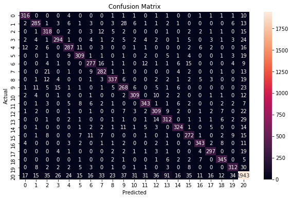

```
0:yes, 1:no, 2:up, 3:down, 4:left, 5:right, 6:on, 7:off, 8:stop, 9:go, 10:zero, 11:one, 12:two, 13:three, 14:four, 15:five, 16:six, 17:seven, 18:eight, 19:nine, 20:unknown

Test set: Average loss: 0.6591, Accuracy: 8082/9708 (83.25%)
```

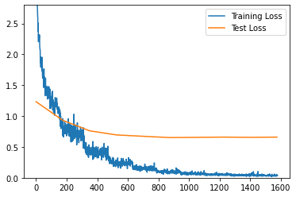

```
ELAPSED TIME: 412.0s
```

```python
model_alpha_instance = model_alpha()
weighted_loss = nn.CrossEntropyLoss(weight=weights)
loss = nn.CrossEntropyLoss()
optimizer = torch.optim.Adam(model_alpha_instance.parameters(), lr=learning_rate)
scheduler = torch.optim.lr_scheduler.StepLR(optimizer, step_size=1, gamma=gamma)
# we will set a dynamical learning rate trhough the gamma factor. In particular, every step_size epochs
# the learning rate will be multiplied by gamma (0.7 in our case)

loss_train, loss_test, acc_test, elapsed = experiment(model_alpha_instance,
                                                      device,
                                                      weighted_loss,
                                                      loss,
                                                      optimizer,
                                                      train_loader,
                                                      test_loader,
                                                      scheduler,
                                                      name='Model_Alpha_',
                                                      save_model=True)
```

Analysing the Train-Test loss plot, we see that the monotonous increase in test set accuracy for every epoch until the final 83.25% is justified by the monotonous decrease of the Test loss until the final plateau, indicating no apparent overfitting.

Attending the confusion matrix, some similarly sounding words have been confused (for exmaple 28 "no"-s were predicted ot be "go"-s). However, the main source of confusion and lack of accuracy comes from the broad class "unknown". Many words that should be recognized as "unknown" are confused with accepted words, and some accepted words are seen as noise "unknown"-s. Perhaps this could be better managed with an alternative strategy to the weighting we used in the loss (a bigger weight for or maybe reducing the number of samples of "unknown" for the training).

In any case, the main objective of the model is to predict one of the accepted words, for example simulating that we press the button for recognition whenever we want one of those words to be recognized. In such a case, requiring to recognize the noise category "unknown" is not that primary. Thus, as for the accepted words the confusion is rather small looking at the confusion matrix, we conclude the model with success.

We collect the metrics for the model and plot its hidden layer structure using "hiddenlayer". Of course, we get the model that was described in Section (C).

```python
accuracies['model_alpha']=acc_test[-1]
times['model_alpha'] = elapsed
params['model_alpha'] = compute_model_parameter_number(model_alpha_instance)
flops['model_alpha'] = compute_parameters_and_flops(model_alpha_instance)[0]
show_model_structure_hiddenlayer(model_alpha_instance)
```

```
# trainable parameters: 170,519,646
[INFO] Register count_convNd() for <class 'torch.nn.modules.conv.Conv2d'>.
[INFO] Register count_linear() for <class 'torch.nn.modules.linear.Linear'>.
[INFO] Register zero_ops() for <class 'torch.nn.modules.dropout.Dropout'>.
[INFO] Register count_bn() for <class 'torch.nn.modules.batchnorm.BatchNorm2d'>.
[WARN] Cannot find rule for <class '__main__.model_alpha'>. Treat it as zero Macs and zero Params.
model_alpha | 170.52 Params(M) | 189.080 FLOPs(M)
```

[figure not shown]

We test the model in my own recordings, just for fun.

```python
predictions = torch.argmax(model_alpha_instance(custom_TestX), dim=0)

print(f"The custom recordings were correctly predicted with an accuracy of {100*torch.sum(predictions==custom_y)/21}%")
print(f"Failed predictions were {np.array(classes_to_recognize)[torch.logical_not(predictions==custom_y).to('cpu')]}")
```

```
The custom recordings were correctly predicted with an accuracy of 95.23809814453125%
Failed predictions were ['one']
```

It seems like my speech is pretty clear! Only one of the custom words was incorrectly labeled ("one")!

## D.2) model_beta

```
----------------------------------------------------------------------------------------------------
STARTING EXPERIMENT Model_Beta_
----------------------------------------------------------------------------------------------------
EPOCH 1
```

```
Test set: Average loss: 2.1163, Accuracy: 3256/9708 (33.54%)

EPOCH 2
```

```
Test set: Average loss: 1.9078, Accuracy: 4302/9708 (44.31%)

EPOCH 3
```

```
Test set: Average loss: 2.0824, Accuracy: 4610/9708 (47.49%)

EPOCH 4
```

```
Test set: Average loss: 1.7300, Accuracy: 5542/9708 (57.09%)

EPOCH 5
```

```
Test set: Average loss: 2.0108, Accuracy: 5449/9708 (56.13%)

EPOCH 6
```

```
Test set: Average loss: 2.1000, Accuracy: 5536/9708 (57.03%)

EPOCH 7
```

```
Test set: Average loss: 2.0871, Accuracy: 5703/9708 (58.75%)

EPOCH 8
```

```
Test set: Average loss: 2.0501, Accuracy: 5878/9708 (60.55%)

EPOCH 9
```

```
Test set: Average loss: 2.1902, Accuracy: 5782/9708 (59.56%)

EPOCH 10
```

```
Test set: Average loss: 2.2773, Accuracy: 5776/9708 (59.50%)
```

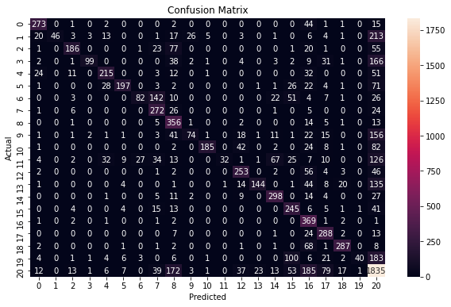

```
0:yes, 1:no, 2:up, 3:down, 4:left, 5:right, 6:on, 7:off, 8:stop, 9:go, 10:zero, 11:one, 12:two, 13:three, 14:four, 15:five, 16:six, 17:seven, 18:eight, 19:nine, 20:unknown

Test set: Average loss: 2.2773, Accuracy: 5776/9708 (59.50%)
```

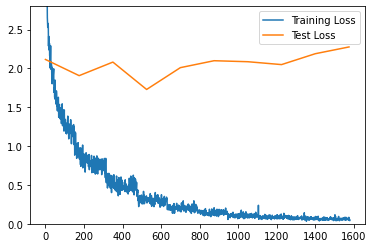

```
ELAPSED TIME: 397.8s
```

```python
model_beta_instance = model_beta()
weighted_loss = nn.CrossEntropyLoss(weight=weights)
loss = nn.CrossEntropyLoss()
optimizer = torch.optim.Adam(model_beta_instance.parameters(), lr=learning_rate)
scheduler = torch.optim.lr_scheduler.StepLR(optimizer, step_size=1, gamma=gamma)
# we will set a dynamical learning rate trhough the gamma factor. In particular, every step_size epochs
# the learning rate will be multiplied by gamma (0.7 in our case)

loss_train, loss_test, acc_test, elapsed = experiment(model_beta_instance,
                                                      device,
                                                      weighted_loss,
                                                      loss,
                                                      optimizer,
                                                      train_loader,
                                                      test_loader,
                                                      scheduler,
                                                      name='Model_Beta_',
                                                      save_model=True)
```

In this case, we see that the training tended towards a very intense overfitting, as even if the train loss was reduced a lot, the test loss did not get much smaller than its initial value. With it, the accuracy on the test set was only 59.50% after the 10 epochs, with a maximum of 60.55% in epoch 8. A very poor result.

```python
accuracies['model_beta']=acc_test[-1]
times['model_beta'] = elapsed
params['model_beta'] = compute_model_parameter_number(model_beta_instance)
flops['model_beta'] = compute_parameters_and_flops(model_beta_instance)[0]
show_model_structure_hiddenlayer(model_beta_instance)
```

```
# trainable parameters: 160,313,031
[INFO] Register count_convNd() for <class 'torch.nn.modules.conv.Conv2d'>.
[INFO] Register count_linear() for <class 'torch.nn.modules.linear.Linear'>.
[INFO] Register zero_ops() for <class 'torch.nn.modules.dropout.Dropout'>.
[INFO] Register count_bn() for <class 'torch.nn.modules.batchnorm.BatchNorm2d'>.
[WARN] Cannot find rule for <class '__main__.model_beta'>. Treat it as zero Macs and zero Params.
model_beta | 160.31 Params(M) | 172.245 FLOPs(M)
```

[figure not shown]

```python
predictions = torch.argmax(model_beta_instance(custom_TestX), dim=0)

print(f"The custom recordings were correctly predicted with an accuracy of {100*torch.sum(predictions==custom_y)/21}%")
print(f"Failed predictions were {np.array(classes_to_recognize)[torch.logical_not(predictions==custom_y).to('cpu')]}")
```

```
The custom recordings were correctly predicted with an accuracy of 85.71428680419922%
Failed predictions were ['on' 'one' 'five']
```

## D.3) model_gamma

```
----------------------------------------------------------------------------------------------------
STARTING EXPERIMENT Model_Gamma_
----------------------------------------------------------------------------------------------------
EPOCH 1
```

```
Test set: Average loss: 1.1538, Accuracy: 5943/9708 (61.22%)

EPOCH 2
```

```
Test set: Average loss: 0.8784, Accuracy: 6858/9708 (70.64%)

EPOCH 3
```

```
Test set: Average loss: 0.7403, Accuracy: 7385/9708 (76.07%)

EPOCH 4
```

```
Test set: Average loss: 0.6594, Accuracy: 7677/9708 (79.08%)

EPOCH 5
```

```
Test set: Average loss: 0.6501, Accuracy: 7797/9708 (80.32%)

EPOCH 6
```

```
Test set: Average loss: 0.6200, Accuracy: 7990/9708 (82.30%)

EPOCH 7
```

```
Test set: Average loss: 0.6438, Accuracy: 7942/9708 (81.81%)

EPOCH 8
```

```
Test set: Average loss: 0.6240, Accuracy: 8051/9708 (82.93%)

EPOCH 9
```

```
Test set: Average loss: 0.6158, Accuracy: 8102/9708 (83.46%)

EPOCH 10
```

```
Test set: Average loss: 0.6257, Accuracy: 8082/9708 (83.25%)
```

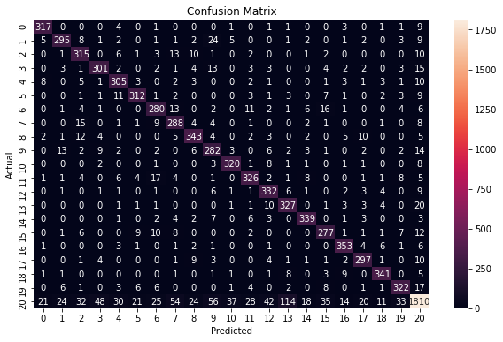

```
0:yes, 1:no, 2:up, 3:down, 4:left, 5:right, 6:on, 7:off, 8:stop, 9:go, 10:zero, 11:one, 12:two, 13:three, 14:four, 15:five, 16:six, 17:seven, 18:eight, 19:nine, 20:unknown

Test set: Average loss: 0.6257, Accuracy: 8082/9708 (83.25%)
```

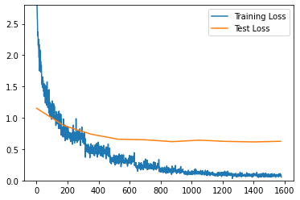

[output not shown]

```python
model_gamma_instance = model_gamma()
weighted_loss = nn.CrossEntropyLoss(weight=weights)
loss = nn.CrossEntropyLoss()
optimizer = torch.optim.Adam(model_gamma_instance.parameters(), lr=learning_rate)
scheduler = torch.optim.lr_scheduler.StepLR(optimizer, step_size=1, gamma=gamma)
# we will set a dynamical learning rate trhough the gamma factor. In particular, every step_size epochs
# the learning rate will be multiplied by gamma (0.7 in our case)

loss_train, loss_test, acc_test, elapsed = experiment(model_gamma_instance,
                                                      device,
                                                      weighted_loss,
                                                      loss,
                                                      optimizer,
                                                      train_loader,
                                                      test_loader,
                                                      scheduler,
                                                      name='Model_Gamma_',
                                                      save_model=True)
```

Again, some similarly sounding words are confused (17 "one"-s as "on"-s for instance). However, the main confusions turn out to be again with respect to the "unknown" word category. Many of the words that should be unknown are classified as being some of the accepted words. Nonetheless, we conclude the same as for model_alpha.

```python
accuracies['model_gamma']=acc_test[-1]
times['model_gamma'] = elapsed
params['model_gamma'] = compute_model_parameter_number(model_gamma_instance)
flops['model_gamma'] = compute_parameters_and_flops(model_gamma_instance)[0]
show_model_structure_hiddenlayer(model_gamma_instance)
```

```
# trainable parameters: 27,289,996
[INFO] Register count_convNd() for <class 'torch.nn.modules.conv.Conv2d'>.
[INFO] Register count_linear() for <class 'torch.nn.modules.linear.Linear'>.
[INFO] Register zero_ops() for <class 'torch.nn.modules.dropout.Dropout'>.
[INFO] Register count_bn() for <class 'torch.nn.modules.batchnorm.BatchNorm2d'>.
[WARN] Cannot find rule for <class '__main__.model_gamma'>. Treat it as zero Macs and zero Params.
model_gamma | 27.29 Params(M) | 46.965 FLOPs(M)
```

[figure not shown]

```python
predictions = torch.argmax(model_gamma_instance(custom_TestX), dim=0)

print(f"The custom recordings were correctly predicted with an accuracy of {100*torch.sum(predictions==custom_y)/21}%")
```

```
The custom recordings were correctly predicted with an accuracy of 100.0%
```

This model seems to know well my speech!